# N V AJAY_22A_Project 2_Time series analysis

This is a R Notebook that does Time Series modelling for the stock ‘**HDFCBANK**’. The source of data is ‘*YAHOO FINANCE*’. The time period is *‘2009-01-01’* to *‘2023-12-31’* and periodicity considered is daily.

```r
# # Required Packages
packages = c('quantmod','car','forecast','tseries','FinTS', 'rugarch','utf8','ggplot2')
#
# # Install all Packages with Dependencies
#install.packages(packages, dependencies = TRUE){install the packages if you dont have it already}
#
# # Load all Packages
lapply(packages, require, character.only = TRUE)
```

```
[[1]]
[1] TRUE

[[2]]
[1] TRUE

[[3]]
[1] TRUE

[[4]]
[1] TRUE

[[5]]
[1] TRUE

[[6]]
[1] TRUE

[[7]]
[1] TRUE

[[8]]
[1] TRUE
```

```r
getSymbols(Symbols = 'HDFCBANK.NS',
           src = 'yahoo',
           from = as.Date('2009-01-01'),
           to = as.Date('2023-12-31'),
           periodicity = 'daily')
```

```
[1] "HDFCBANK.NS"
```

```r
HDFCBANK_price = na.omit(HDFCBANK.NS$HDFCBANK.NS.Adjusted) # Adjusted Closing Price
class(HDFCBANK_price) # xts (Time-Series) Object
```

```
[1] "xts" "zoo"
```

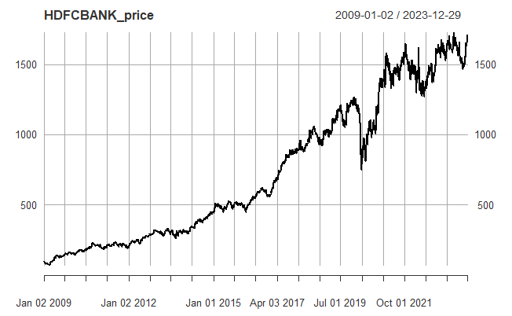

```r
plot(HDFCBANK_price)
```

```r
class(HDFCBANK_price) # xts (Time-Series) Object
```

```
[1] "xts" "zoo"
```

```r
# Augmented Dickey-Fuller (ADF) Test for Stationarity with HDFCBANK Data
# *******************************************************************

adf_test_HDFCBANK_P = adf.test(HDFCBANK_price); adf_test_HDFCBANK_P # Inference : HDFCBANK_Price Time-Series is Non-Stationary
```

```
    Augmented Dickey-Fuller Test

data:  HDFCBANK_price
Dickey-Fuller = -2.9252, Lag order = 15, p-value = 0.1866
alternative hypothesis: stationary
```

Analysis:

**Objective**: To analyze the daily returns of HDFCBANK stock from 2009-01-01 to 2023-12-31.

**Analysis**: Extracted the adjusted closing prices of HDFCBANK stock, performed ADF Test, and visualized them.

**Result**: The ‘HDFCBANK_price’ is not stationary as p-value > critical value(0.05).

**Implication**: The stock needs to be made stationary using log returns method.

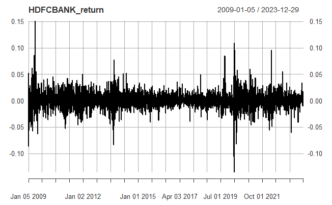

```r
#HDFCBANK_price was not stationary therefore for HDFCBANK_return
#ADF test for Stationery
HDFCBANK_return = na.omit(diff(log(HDFCBANK_price))); plot(HDFCBANK_return)
```

```r
adf_test_HDFCBANK = adf.test(HDFCBANK_return); adf_test_HDFCBANK
```

```
    Augmented Dickey-Fuller Test

data:  HDFCBANK_return
Dickey-Fuller = -16.03, Lag order = 15, p-value = 0.01
alternative hypothesis: stationary
```

ANalysis:

**Objective**: To conduct an Augmented Dickey-Fuller (ADF) test for stationarity on the daily returns of HDFCBANK stock.

**Analysis**: calculated daily returns, and visualized them. Performed the ADF test using the ‘adf.test’ function and obtained results.

**Result**: The Augmented Dickey-Fuller test for stationarity on HDFCBANK daily returns yields the following results:

Dickey-Fuller statistic: -16.03 Lag order: 15 p-value: 0.01 Alternative hypothesis: Stationary

**Implication**: The ADF test suggests that the daily returns of HDFCBANK stock are likely stationary. The small p-value (0.01) indicates evidence against the null hypothesis of non-stationarity. Therefore, there is reason to believe that the HDFCBANK stock returns exhibit stationarity, which is important for certain time series analyses.

```r
#Autocorrelation test
# Ljung-Box Test for Autocorrelation
lb_test_ds_HDFCBANK = Box.test(HDFCBANK_return); lb_test_ds_HDFCBANK
```

```
    Box-Pierce test

data:  HDFCBANK_return
X-squared = 5.8853, df = 1, p-value = 0.01527
```

```r
#If autocorrelation exists then autoARIMA
```

Analysis:

**Objective**: Performing a Ljung-Box test for autocorrelation on HDFCBANK daily returns.

**Result**: The Ljung-Box test for autocorrelation on HDFCBANK daily returns yields the following results:

X-squared statistic: 5.8852 Degrees of freedom: 1 p-value: 0.01527

**Implication**: The Ljung-Box test indicates moderate evidence of autocorrelation in HDFCBANK daily returns. The obtained p-value (0.01527) suggests a significant departure from the null hypothesis of no autocorrelation.

**Action Step**: Given the presence of autocorrelation, it may be advisable to consider an autoARIMA model for time series forecasting. AutoARIMA can automatically select an appropriate ARIMA model with differencing to account for the observed autocorrelation.

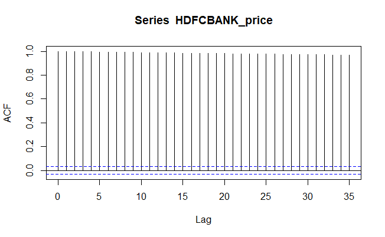

```r
#ACF and PCF

acf(HDFCBANK_price) # ACF of HDFCBANK Series
```

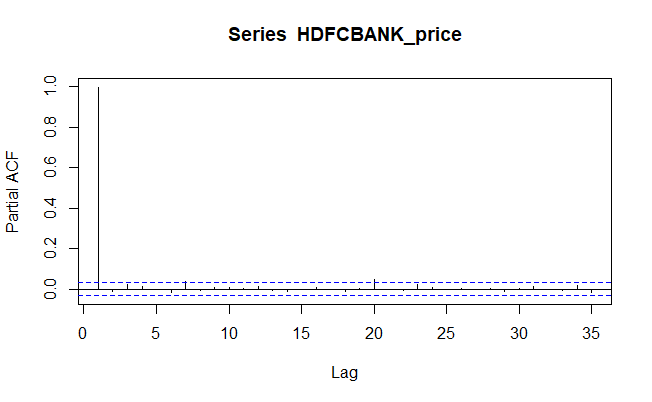

```r
pacf(HDFCBANK_price) # PACF of HDFCBANK Series
```

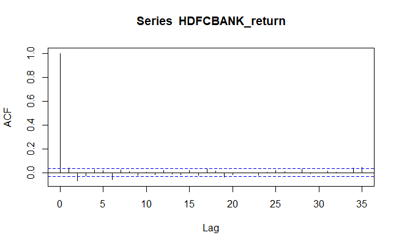

```r
acf(HDFCBANK_return) # ACF of HDFCBANK Difference (Stationary) Series
```

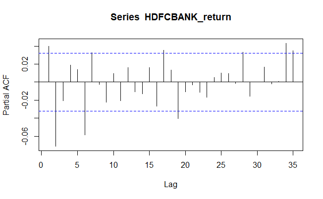

```r
pacf(HDFCBANK_return) # PACF of HDFCBANK Difference (Stationary) Series
```

```r
#AutoArima
arma_pq_ds_H = auto.arima(HDFCBANK_return); arma_pq_ds_H
```

```
Series: HDFCBANK_return
ARIMA(3,0,0) with non-zero mean

Coefficients:
         ar1      ar2      ar3   mean
      0.0412  -0.0706  -0.0209  8e-04
s.e.  0.0164   0.0164   0.0165  2e-04

sigma^2 = 0.0002362:  log likelihood = 10189.58
AIC=-20369.17   AICc=-20369.15   BIC=-20338.09
```

```r
arma_pq_H = auto.arima(HDFCBANK_price); arma_pq_H
```

```
Series: HDFCBANK_price
ARIMA(2,1,2) with drift

Coefficients:
          ar1     ar2     ma1     ma2   drift
      -0.0685  -0.577  0.1155  0.5202  0.4387
s.e.   0.2190   0.095  0.2292  0.1033  0.2082

sigma^2 = 162.4:  log likelihood = -14648.07
AIC=29308.15   AICc=29308.17   BIC=29345.44
```

Analysis:

**Objective**: Perform autoARIMA modeling on HDFCBANK daily returns and adjusted closing prices.

1.1. Daily Returns AutoARIMA Modeling

**Analysis**: Utilized the ‘auto.arima’ function to automatically select the ARIMA model for daily returns.

**Results**: For Daily Returns (‘HDFCBANK_return’): The autoARIMA model suggests an ARIMA(3,0,0) with non-zero mean.

Coefficients: ar1 to ar3, mean Sigma^2 (variance): 0.0002362 Log likelihood: 10189.58 AIC: -20369.17, AICc: -20369.15, BIC: -20338.09 1.2. Adjusted Closing Prices AutoARIMA Modeling

**Analysis**: Utilized the ‘auto.arima’ function to automatically select the ARIMA model for adjusted closing prices.

**Results**: For Adjusted Closing Prices (‘HDFCBANK_price’): The autoARIMA model suggests an ARIMA(2,1,2) with drift.

Coefficients: ar1 to ar2, ma1 to ma2, drift sigma^2 = 162.4: log likelihood = -14648.07 AIC=29308.15 AICc=29308.17 BIC=29345.44

**Implication**: The autoARIMA models provide a statistical framework to capture patterns in HDFCBANK daily returns and adjusted closing prices. These models can be used for forecasting future values, and the AIC, AICc, and BIC values help in model comparison.

**ARIMA EQUATION**

The ARIMA(3, 0, 0) model can be represented by the following equation:

Y_t = c + Φ1 Y_(t-1) + Φ2 Y_(t-2) + Φ3 Y_(t-3) + ε_t

where Φ are the autoregressive (AR) coefficients for lags Y_t is the actual value at time t. c is the constant term (intercept). ε_t is the white noise error term at time t

**Difference between Visual Lags from ACF and PACF and Auto arima lags**

For Series HDFCBANK_return ACF cuts off after 0 lags PACF cuts off after 2 lags

But the order we get from auto arima is p = 3 lags and q = 0 lags

*Note: Interpretation of the coefficients and model selection details may require further analysis based on the specific context of the financial data.*

```r
#Arima manuplation
arma30 = arima(HDFCBANK_return, order = c(3,0,0)); arma30
```

```
Call:
arima(x = HDFCBANK_return, order = c(3, 0, 0))

Coefficients:
         ar1      ar2      ar3  intercept
      0.0412  -0.0706  -0.0209      8e-04
s.e.  0.0164   0.0164   0.0165      2e-04

sigma^2 estimated as 0.000236:  log likelihood = 10189.58,  aic = -20369.17
```

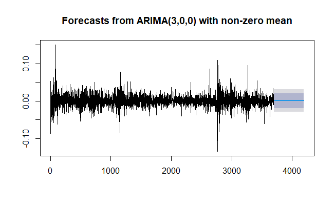

```r
ds_fpq_HDFCBANK = forecast(arma30, h = 500)
plot(ds_fpq_HDFCBANK)
```

Analysis:

2. ARIMA(3, 0, 0) Model and Forecast

**Objective**: Fit an ARIMA(3, 0, 0) model to HDFCBANK daily returns and generate forecasts.

2.1. ARIMA(3, 0, 0) Model

**Analysis**: Utilized the ‘arima’ function to fit the ARIMA model.

**Results**: ARIMA Model (3, 0, 0) Coefficients:

AR: ar1 to ar3 Intercept term Sigma^2 (variance) estimated as 0.000236 Log likelihood: 10189.58 AIC: -20369.17 2.2. Forecasting

**Forecasting**: Generated forecasts for the next 500 time points using the fitted ARIMA(3, 0, 0) model.

**Plot**: The plot displays the original time series of daily returns along with the forecasted values.

**Implication**: The ARIMA(3, 0, 0) model provides insights into the historical patterns of HDFCBANK daily returns. The generated forecasts can be valuable for future predictions, and the plot visually represents the model’s performance.

*Note: Interpretation of coefficients and model evaluation details may require further analysis based on the specific context of the financial data.*

```r
#Autocorrelation test
# Ljung-Box Test for Autocorrelation
lb_test_ds_AR = Box.test(arma30$residuals); lb_test_ds_AR
```

```
    Box-Pierce test

data:  arma30$residuals
X-squared = 0.00070388, df = 1, p-value = 0.9788
```

```r
#After this no autocorrelation exists
```

Analysis:

3. Ljung-Box Test Results

**Objective**: Assess autocorrelation in the residuals of the ARIMA(3, 0, 0) model.

3.1. Ljung-Box Test Statistics

**Results**:

X-squared statistic: 0.00070386 Degrees of freedom: 1 p-value: 0.9788

3.2. **Implication** The Ljung-Box test suggests no significant autocorrelation in the residuals of the ARIMA(3, 0, 0) model. The high p-value (0.9788) indicates no evidence against the null hypothesis of no autocorrelation.

3.3. **Action** The absence of autocorrelation in residuals is a positive outcome, suggesting that the ARIMA model adequately captures the temporal patterns in the time series.

*Note: Interpretation may vary based on the specific context of the financial data and the assumptions underlying the time series analysis.*

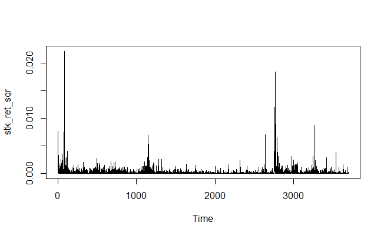

```r
# Test for Volatility Clustering or Heteroskedasticity: Box Test
stk_ret_sqr = arma30$residuals^2 # Return Variance (Since Mean Returns is approx. 0)
plot(stk_ret_sqr)
```

```r
stk_ret_sqr_box_test = Box.test(stk_ret_sqr, lag = 10) # H0: Return Variance Series is Not Serially Correlated
stk_ret_sqr_box_test # Inference : Return Variance Series is Heteroskedastic (Has Volatility Clustering)
```

```
    Box-Pierce test

data:  stk_ret_sqr
X-squared = 1049, df = 10, p-value < 2.2e-16
```

```r
# Test for Volatility Clustering or Heteroskedasticity: ARCH Test
stk_ret_arch_testH = ArchTest(arma30$residuals, lags = 10) # H0: No ARCH Effects
stk_ret_arch_testH # Inference : Return Series is Heteroskedastic (Has Volatility Clustering)
```

```
    ARCH LM-test; Null hypothesis: no ARCH effects

data:  arma30$residuals
Chi-squared = 519.1, df = 10, p-value < 2.2e-16
```

Analysis:

4. Volatility Clustering Tests

**Objective**: Assess the presence of volatility clustering or heteroskedasticity in the residuals of the ARIMA(3, 0, 0) model.

**Analysis**: Conducted Box test and ARCH test on the squared residuals to assess the presence of volatility clustering.

4.1. Box Test for Volatility Clustering

X-squared Statistic: 1049 Degrees of Freedom: 10 p-value: < 2.2e-16

**Results and Inference**:

*The Box test indicates significant evidence against the null hypothesis, suggesting that the return variance series exhibits volatility clustering or heteroskedasticity.*

4.2. ARCH Test for Volatility Clustering

Chi-squared Statistic: 519.1 Degrees of Freedom: 10 p-value: < 2.2e-16

**Results and Inference**: *The ARCH test provides strong evidence against the null hypothesis. It supporting the presence of ARCH effects in the return series*. *This implies that the returns have volatility clustering as per the ARCH Test.*

4.3. **Implication** The results from both tests suggest that the residuals of the ARIMA(3, 0, 0) model exhibit significant volatility clustering or heteroskedasticity. Understanding and accounting for this pattern in volatility is essential for risk management and forecasting. Hence, we proceed with Residual modelling assuming Heteroskedasticity.

*Note: Interpretation may vary based on the specific context of the financial data and the assumptions underlying the time series analysis.*

```r
#Garch model
garch_model1H = ugarchspec(variance.model = list(model = 'sGARCH', garchOrder = c(1,1)), mean.model = list(armaOrder = c(0,0), include.mean = TRUE))
nse_ret_garch1H = ugarchfit(garch_model1H, data = arma30$residuals)
nse_ret_garch1H
```

```
*---------------------------------*
*          GARCH Model Fit        *
*---------------------------------*

Conditional Variance Dynamics
-----------------------------------
GARCH Model : sGARCH(1,1)
Mean Model  : ARFIMA(0,0,0)
Distribution    : norm

Optimal Parameters
------------------------------------
        Estimate  Std. Error  t value Pr(>|t|)
mu      0.000022    0.000207   0.1070 0.914790
omega   0.000003    0.000001   2.3459 0.018983
alpha1  0.057278    0.007411   7.7290 0.000000
beta1   0.927783    0.009165 101.2275 0.000000

Robust Standard Errors:
        Estimate  Std. Error  t value Pr(>|t|)
mu      0.000022    0.000214  0.10354 0.917532
omega   0.000003    0.000006  0.50193 0.615719
alpha1  0.057278    0.025080  2.28377 0.022385
beta1   0.927783    0.036837 25.18584 0.000000

LogLikelihood : 10612.34

Information Criteria
------------------------------------

Akaike       -5.7404
Bayes        -5.7337
Shibata      -5.7404
Hannan-Quinn -5.7380

Weighted Ljung-Box Test on Standardized Residuals
------------------------------------
                        statistic p-value
Lag[1]                    0.05513  0.8144
Lag[2*(p+q)+(p+q)-1][2]   0.90257  0.5309
```

[output cut: 19 more lines]

```
Nyblom stability test
------------------------------------
Joint Statistic:  18.5662
Individual Statistics:
mu     0.5646
omega  1.9420
alpha1 0.1899
beta1  0.2201

Asymptotic Critical Values (10% 5% 1%)
Joint Statistic:         1.07 1.24 1.6
Individual Statistic:    0.35 0.47 0.75

Sign Bias Test
------------------------------------
```

|  | t-value | prob | sig |
| --- | --- | --- | --- |
| Sign Bias | 0.6664844 | 0.5051432 |  |
| Negative Sign Bias | 0.1142942 | 0.9090108 |  |
| Positive Sign Bias | 0.9734020 | 0.3304174 |  |
| Joint Effect | 3.3251332 | 0.3441599 |  |

```
Adjusted Pearson Goodness-of-Fit Test:
------------------------------------
  group statistic p-value(g-1)
1    20      91.9    1.525e-11
2    30     105.2    1.424e-10
3    40     118.4    6.223e-10
4    50     144.4    2.415e-11


Elapsed time : 0.2973919
```

```r
garch_model2H = ugarchspec(variance.model = list(model = 'sGARCH', garchOrder = c(1,1)), mean.model = list(armaOrder = c(3,0), include.mean = FALSE))
nse_ret_garch2H = ugarchfit(garch_model2H, data = arma30$residuals)
nse_ret_garch2H
```

```
*---------------------------------*
*          GARCH Model Fit        *
*---------------------------------*

Conditional Variance Dynamics
-----------------------------------
GARCH Model : sGARCH(1,1)
Mean Model  : ARFIMA(3,0,0)
Distribution    : norm

Optimal Parameters
------------------------------------
        Estimate  Std. Error   t value Pr(>|t|)
ar1     0.005263    0.017549   0.29988 0.764269
ar2     0.012897    0.017466   0.73836 0.460293
ar3     0.016614    0.017346   0.95776 0.338182
omega   0.000003    0.000001   2.33441 0.019574
alpha1  0.054429    0.007184   7.57626 0.000000
beta1   0.931077    0.008831 105.43091 0.000000

Robust Standard Errors:
        Estimate  Std. Error  t value Pr(>|t|)
ar1     0.005263    0.019256  0.27329 0.784631
ar2     0.012897    0.017115  0.75351 0.451141
ar3     0.016614    0.017515  0.94857 0.342839
omega   0.000003    0.000006  0.47896 0.631967
alpha1  0.054429    0.026018  2.09195 0.036443
beta1   0.931077    0.037261 24.98824 0.000000

LogLikelihood : 10606.29

Information Criteria
------------------------------------

Akaike       -5.7361
Bayes        -5.7260
Shibata      -5.7361
Hannan-Quinn -5.7325

Weighted Ljung-Box Test on Standardized Residuals
```

[output cut: 25 more lines]

```
Joint Statistic:  25.1904
Individual Statistics:
ar1    0.1599
ar2    0.1355
ar3    0.1449
omega  2.4999
alpha1 0.1653
beta1  0.2126

Asymptotic Critical Values (10% 5% 1%)
Joint Statistic:         1.49 1.68 2.12
Individual Statistic:    0.35 0.47 0.75

Sign Bias Test
------------------------------------
```

|  | t-value | prob | sig |
| --- | --- | --- | --- |
| Sign Bias | 0.4440115 | 0.6570603 |  |
| Negative Sign Bias | 0.1507069 | 0.8802151 |  |
| Positive Sign Bias | 1.5060321 | 0.1321445 |  |
| Joint Effect | 4.7779809 | 0.1887953 |  |

```
Adjusted Pearson Goodness-of-Fit Test:
------------------------------------
  group statistic p-value(g-1)
1    20     94.28    5.732e-12
2    30    115.48    2.842e-12
3    40    116.45    1.221e-09
4    50    145.48    1.685e-11


Elapsed time : 0.518213
```

```r
# Test for Volatility Clustering or Heteroskedasticity: ARCH Test
gar_resdH = residuals(nse_ret_garch2H)^2
stk_ret_arch_test1H = ArchTest(gar_resdH, lags = 1) # H0: No ARCH Effects
stk_ret_arch_test1H # Inference : Return Series(residuals) is not Heteroskedastic
```

```
    ARCH LM-test; Null hypothesis: no ARCH effects

data:  gar_resdH
Chi-squared = 0.018609, df = 1, p-value = 0.8915
```

```r
# Extract coefficients
coefficients_garch2H <- coef(nse_ret_garch2H)
print(coefficients_garch2H)
```

```
         ar1          ar2          ar3        omega       alpha1
5.262566e-03 1.289651e-02 1.661382e-02 3.066612e-06 5.442929e-02
       beta1
9.310772e-01
```

```r
# Extract other information
fitted_values <- fitted(nse_ret_garch2H); fitted_values
```

```
           m.c.seq.row..seq.n...seq.col..drop...FALSE.
0001-01-01                                0.000000e+00
0002-01-01                                0.000000e+00
0003-01-01                                0.000000e+00
0004-01-01                                6.350289e-04
0005-01-01                               -2.098444e-04
0006-01-01                               -1.363125e-03
0007-01-01                               -9.028430e-05
0008-01-01                               -6.068999e-04
0009-01-01                               -7.347084e-04
0010-01-01                               -8.712498e-04
       ...
3687-01-01                               -1.401073e-04
3688-01-01                                1.024350e-04
3689-01-01                                1.948587e-04
3690-01-01                                1.650949e-05
3691-01-01                               -2.840346e-05
3692-01-01                                7.756411e-05
3693-01-01                                1.873933e-04
3694-01-01                                1.782388e-04
3695-01-01                               -2.283188e-05
3696-01-01                                2.703681e-04
```

Analysis:

**Objective**: To fit GARCH models to the residuals of the ARIMA(3, 0, 0) model and test for volatility clustering.

**Analysis**: Fitted two GARCH models (‘garch_model1H’ and ‘garch_model2H’) to the residuals and performed an ARCH test on squared residuals.

**Results:**:

GARCH Model 1:

sGARCH(1,1) model with ARIMA(0,0,0) mean. Optimal Parameters: Mean (mu): 0.000022 Omega: 0.000003 Alpha1: 0.057278 Beta1: 0.927783 Log likelihood: 10612.34 Weighted Ljung-Box Test on Standardized Residuals and Squared Residuals show no significant autocorrelation. Weighted ARCH LM Tests indicate no evidence of ARCH effects.

GARCH Model 2:

[output not shown]

*Note: It’s important to note that selecting the best GARCH model often involves a combination of various factors, and the choice may depend on the specific research question and desired level of complexity.*

**Implication**: Both GARCH models suggest that the residuals do not exhibit significant volatility clustering.

```r
garcH_modelf = ugarchspec(variance.model = list(model = 'sGARCH', garchOrder = c(1,1)), mean.model = list(armaOrder = c(3,0), include.mean = FALSE))
stk_ret_garcH = ugarchfit(garcH_modelf, data = HDFCBANK_return); stk_ret_garcH
```

```
*---------------------------------*
*          GARCH Model Fit        *
*---------------------------------*

Conditional Variance Dynamics
-----------------------------------
GARCH Model : sGARCH(1,1)
Mean Model  : ARFIMA(3,0,0)
Distribution    : norm

Optimal Parameters
------------------------------------
        Estimate  Std. Error   t value Pr(>|t|)
ar1     0.051775    0.017553   2.94968 0.003181
ar2    -0.053552    0.017492  -3.06146 0.002203
ar3     0.003209    0.017368   0.18478 0.853403
omega   0.000003    0.000001   2.36591 0.017986
alpha1  0.053940    0.007019   7.68459 0.000000
beta1   0.931467    0.008644 107.75434 0.000000

Robust Standard Errors:
        Estimate  Std. Error  t value Pr(>|t|)
ar1     0.051775    0.019356  2.67488 0.007476
ar2    -0.053552    0.017530 -3.05490 0.002251
ar3     0.003209    0.017418  0.18425 0.853819
omega   0.000003    0.000006  0.48867 0.625077
alpha1  0.053940    0.024752  2.17920 0.029317
beta1   0.931467    0.035981 25.88785 0.000000

LogLikelihood : 10596

Information Criteria
------------------------------------

Akaike       -5.7305
Bayes        -5.7204
Shibata      -5.7305
Hannan-Quinn -5.7269

Weighted Ljung-Box Test on Standardized Residuals
```

[output cut: 25 more lines]

```
Joint Statistic:  24.7589
Individual Statistics:
ar1    0.1689
ar2    0.1257
ar3    0.1407
omega  2.3178
alpha1 0.1681
beta1  0.2204

Asymptotic Critical Values (10% 5% 1%)
Joint Statistic:         1.49 1.68 2.12
Individual Statistic:    0.35 0.47 0.75

Sign Bias Test
------------------------------------
```

|  | t-value | prob | sig |
| --- | --- | --- | --- |
| Sign Bias | 0.5248332 | 0.5997306 |  |
| Negative Sign Bias | 0.3805143 | 0.7035856 |  |
| Positive Sign Bias | 1.4927613 | 0.1355851 |  |
| Joint Effect | 4.5832615 | 0.2049827 |  |

```
Adjusted Pearson Goodness-of-Fit Test:
------------------------------------
  group statistic p-value(g-1)
1    20     109.8    8.795e-15
2    30     123.4    1.326e-13
3    40     140.5    2.233e-13
4    50     148.0    7.178e-12


Elapsed time : 0.6741471
```

Analysis:

**Objective**: To fit a GARCH model to the daily returns of HDFCBANK stock and assess the goodness-of-fit using the Adjusted Pearson Goodness-of-Fit Test.

**Analysis**: Used the ‘ugarchspec’ and ‘ugarchfit’ functions to fit a GARCH model and performed the Adjusted Pearson Goodness-of-Fit Test.

**Results**:

GARCH Model:

Adjusted Pearson Goodness-of-Fit Test:

*Note: Interpretation may vary based on the specific context of the financial data and the assumptions underlying the time series analysis.*

```r
# GARCH Forecast
stk_ret_garch_forecast1h = ugarchforecast(stk_ret_garcH, n.ahead = 50); stk_ret_garch_forecast1h
```

```
*------------------------------------*
*       GARCH Model Forecast         *
*------------------------------------*
Model: sGARCH
Horizon: 50
Roll Steps: 0
Out of Sample: 0

0-roll forecast [T0=2023-12-29]:
         Series   Sigma
T+1   9.956e-05 0.01060
T+2  -1.166e-04 0.01067
T+3  -3.852e-06 0.01074
T+4   6.367e-06 0.01080
T+5   1.616e-07 0.01087
T+6  -3.449e-07 0.01093
T+7  -6.080e-09 0.01099
T+8   1.868e-08 0.01105
T+9   1.856e-10 0.01111
T+10 -1.010e-09 0.01117
T+11 -2.296e-12 0.01123
T+12  5.457e-11 0.01128
T+13 -2.933e-13 0.01134
T+14 -2.945e-12 0.01139
T+15  3.836e-14 0.01144
T+16  1.587e-13 0.01150
T+17 -3.286e-15 0.01155
T+18 -8.548e-15 0.01160
T+19  2.428e-16 0.01165
T+20  4.598e-16 0.01169
T+21 -1.663e-17 0.01174
T+22 -2.470e-17 0.01179
T+23  1.087e-18 0.01183
T+24  1.326e-18 0.01188
T+25 -6.885e-20 0.01192
T+26 -7.108e-20 0.01196
T+27  4.262e-21 0.01201
T+28  3.806e-21 0.01205
T+29 -2.593e-22 0.01209
T+30 -2.036e-22 0.01213
T+31  1.556e-23 0.01217
T+32  1.087e-23 0.01221
T+33 -9.235e-25 0.01224
T+34 -5.802e-25 0.01228
T+35  5.431e-26 0.01232
T+36  3.092e-26 0.01235
T+37 -3.170e-27 0.01239
T+38 -1.646e-27 0.01242
T+39  1.838e-28 0.01246
T+40  8.747e-29 0.01249
T+41 -1.059e-29 0.01252
T+42 -4.643e-30 0.01256
T+43  6.076e-31 0.01259
T+44  2.461e-31 0.01262
T+45 -3.470e-32 0.01265
T+46 -1.303e-32 0.01268
T+47  1.974e-33 0.01271
T+48  6.884e-34 0.01274
T+49 -1.118e-34 0.01277
T+50 -3.632e-35 0.01280
```

Analysis:

**Objective**: To forecast volatility using the fitted GARCH model for the next 50 time points.

**Analysis**: Used the ‘ugarchforecast’ function to generate volatility forecasts for the next 50 time points.

**Results**:

GARCH Model Forecast:

Model: sGARCH Horizon: 50 Roll Steps: 0 Out of Sample: 0 0-roll forecast [T0=2023-12-29]:

Forecasted Series (Sigma) for the next 50 time points: T+1 to T+50: Contain forecasted values of volatility.

**Implication**: The forecasted values represent the predicted volatility for the next 50 time points based on the fitted GARCH model. These forecasts can be valuable for risk management, helping to anticipate and plan for potential changes in volatility in the financial time series.

```r
plot(stk_ret_garch_forecast1h)
```

```
Make a plot selection (or 0 to exit):

1:   Time Series Prediction (unconditional)
2:   Time Series Prediction (rolling)
3:   Sigma Prediction (unconditional)
4:   Sigma Prediction (rolling)
```

```r
1
```

```
Make a plot selection (or 0 to exit):

1:   Time Series Prediction (unconditional)
2:   Time Series Prediction (rolling)
3:   Sigma Prediction (unconditional)
4:   Sigma Prediction (rolling)
```

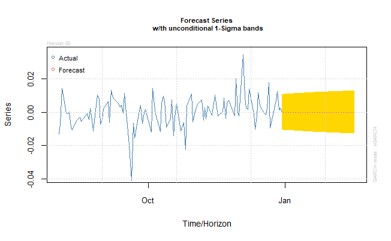

```
Make a plot selection (or 0 to exit):

1:   Time Series Prediction (unconditional)
2:   Time Series Prediction (rolling)
3:   Sigma Prediction (unconditional)
4:   Sigma Prediction (rolling)
```

```r
3
```

[output not shown]

[figure not shown]

```r
2
```